# Project 2 — Data Tidying

Author

Lionel jr. desroses

Published

October 10, 2026

**Introduction**

**Project Overview**

For this project, I plan to work with three independent education-related datasets that can be linked together using the state as a common identifier. The datasets will focus on high school graduation rates, state-level SAT scores, and state-level public education funding. Although each dataset will be analyzed separately as required by the assignment, they all relate to educational outcomes and provide an opportunity to explore broader relationships between academic performance, graduation rates, and school funding.

The goal of this project is to demonstrate how to transform wide-format data into tidy data using the **tidyr** and **dplyr** packages in R. After tidying each dataset, I will perform exploratory analyses, create summary tables, and develop visualizations that highlight patterns within each dataset. Finally, I will combine the tidy datasets to investigate whether states with higher education funding also tend to have higher SAT scores and graduation rates.

**Proposed Approach**

**Dataset 1: High School Graduation Rates**

The first dataset will contain high school graduation rates by state. Since educational datasets are often stored in wide format, with years as separate columns, I expect to use pivot_longer() to transform the data into a tidy structure, where each row represents a state-year observation.After tidying the data, I will create summary tables showing graduation rates by state and identify the states with the highest graduation rates. I will also develop visualizations, such as bar charts, to compare graduation rates across states and highlight the highest-performing states.

**Dataset 2: SAT Scores by State**

The second dataset will contain SAT scores by state. Similar to the graduation dataset, I expect the data may require reshaping and standardizing variable names before analysis.Once the data has been tidied, I will calculate summary statistics and identify which states have the highest average SAT scores. I will then create visualizations to compare SAT performance across states and identify notable patterns or trends.

**Dataset 3: Public Education Funding**

The third dataset will focus on public education funding by state, including per-pupil expenditures and total education spending. This dataset may contain multiple funding categories that will need to be transformed into a tidy format. After cleaning and restructuring the data, I will create summary tables showing the states with the highest education spending and generate visualizations that compare funding levels across states.

**Combined Analysis**

After completing the required analysis for each dataset, I plan to merge the three tidy datasets using the state as the common key. This additional analysis will allow me to explore potential relationships among education funding, SAT scores, and graduation rates.

Specifically, I will investigate questions such as:

- Do states with higher education funding tend to have higher SAT scores?
- Do states with higher graduation rates also have higher SAT scores?
- Is there a relationship between education spending and graduation rates?.

**Expected Challenges**

One challenge will be ensuring that all three datasets use a consistent state identifier. Some datasets may use full state names while others may use abbreviations, requiring additional data cleaning before the datasets can be merged.

.

## Running Code

```r
library(tidyverse)
library(tidyr)
library(dplyr)
library(ggplot2)
library(tibble)
```

## **Dataset 1: High School Graduation Rates**

The original graduation-rate dataset was stored in a wide format where states appeared as column names and graduation years appeared as rows. This structure made analysis difficult because years were stored as observations rather than variables. To create a tidy dataset, the data was first transposed so that each state became a row and each graduation year became a column. The dataset was then reshaped into a long format using pivot_longer(), producing one row per state-year combination.

```r
library(readr)
HS_grad_rate <- read_csv("https://raw.githubusercontent.com/lioneljr17/LDATA607/refs/heads/main/Project2/HS_grad_rate.csv")
#View(HS_grad_rate)

dim(HS_grad_rate)
```

```
[1]  5 53
```

```r
names(HS_grad_rate)
```

```
 [1] "state"                "Vermont"              "Maine"
 [4] "Montana"              "New Hampshire"        "Wyoming"
 [7] "North Dakota"         "Minnesota"            "Alaska"
[10] "Wisconsin"            "Utah"                 "Iowa"
[13] "Hawaii"               "South Dakota"         "Colorado"
[16] "District of Columbia" "Washington"           "Nebraska"
[19] "Michigan"             "Pennsylvania"         "Kansas"
[22] "Idaho"                "Missouri"             "Ohio"
[25] "Oregon"               "Delaware"             "Virginia"
[28] "Connecticut"          "Massachusetts"        "Maryland"
[31] "New Jersey"           "Illinois"             "Indiana"
[34] "North Carolina"       "South Carolina"       "Tennessee"
[37] "Florida"              "Rhode Island"         "Arizona"
[40] "Oklahoma"             "West Virginia"        "Georgia"
[43] "Kentucky"             "Arkansas"             "Alabama"
[46] "New Mexico"           "New York"             "Nevada"
[49] "Louisiana"            "Mississippi"          "Texas"
[52] "California"           "United States"
```

```r
head(HS_grad_rate)
```

```
# A tibble: 5 × 53
  state   Vermont Maine Montana `New Hampshire` Wyoming `North Dakota` Minnesota
  <chr>     <dbl> <dbl>   <dbl>           <dbl>   <dbl>          <dbl>     <dbl>
1 HighSc…    94.9  94.8    94.6            94.4    94.2           94        93.9
2 HighSc…    94.5  94.5    94.6            94.1    94.1           93.8      93.9
3 HighSc…    94.2  94.1    94.5            93.8    93.9           93.5      93.7
4 HighSc…    93.9  93.7    94.4            93.6    93.7           93.3      93.6
5 HighSc…    93.5  93.2    94              93.3    93.6           93.1      93.4
# ℹ 45 more variables: Alaska <dbl>, Wisconsin <dbl>, Utah <dbl>, Iowa <dbl>,
#   Hawaii <dbl>, `South Dakota` <dbl>, Colorado <dbl>,
#   `District of Columbia` <dbl>, Washington <dbl>, Nebraska <dbl>,
#   Michigan <dbl>, Pennsylvania <dbl>, Kansas <dbl>, Idaho <dbl>,
#   Missouri <dbl>, Ohio <dbl>, Oregon <dbl>, Delaware <dbl>, Virginia <dbl>,
#   Connecticut <dbl>, Massachusetts <dbl>, Maryland <dbl>, `New Jersey` <dbl>,
#   Illinois <dbl>, Indiana <dbl>, `North Carolina` <dbl>, …
```

```r
grad_clean <- HS_grad_rate %>%
  column_to_rownames("state") %>%
  t() %>%
  as.data.frame() %>%
  rownames_to_column("state")

names(grad_clean) <- c(
  "state",
  "highschool_2024",
  "highschool_2023",
  "highschool_2022",
  "highschool_2021",
  "highschool_2020"
)

grad_tidy <- grad_clean %>%
  pivot_longer(
    starts_with("highschool_"),
    names_to = "year",
    values_to = "graduation_rate"
  ) %>%
  mutate(
    year = gsub("highschool_", "", year),
    graduation_rate = as.numeric(graduation_rate)
  )
```

```r
top5_grad <- grad_clean %>%
  arrange(desc(highschool_2024)) %>%
  slice_head(n = 5)

top5_grad
```

```
          state highschool_2024 highschool_2023 highschool_2022 highschool_2021
1       Vermont            94.9            94.5            94.2            93.9
2         Maine            94.8            94.5            94.1            93.7
3       Montana            94.6            94.6            94.5            94.4
4 New Hampshire            94.4            94.1            93.8            93.6
5       Wyoming            94.2            94.1            93.9            93.7
  highschool_2020
1            93.5
2            93.2
3            94.0
4            93.3
5            93.6
```

```r
bottom5_grad <- grad_clean %>%
  arrange(highschool_2024) %>%
  slice_head(n = 5)

bottom5_grad
```

```
        state highschool_2024 highschool_2023 highschool_2022 highschool_2021
1  California            84.7            84.6            84.4            84.2
2       Texas            86.0            85.7            85.2            84.8
3 Mississippi            87.1            86.6            86.2            85.6
4   Louisiana            87.3            86.9            86.7            86.2
5      Nevada            87.5            87.4            87.1            87.0
  highschool_2020
1            83.9
2            84.4
3            85.3
4            85.9
5            86.9
```

```r
grad_clean %>%
  arrange(desc(highschool_2024)) %>%
  slice_head(n = 10)
```

```
           state highschool_2024 highschool_2023 highschool_2022
1        Vermont            94.9            94.5            94.2
2          Maine            94.8            94.5            94.1
3        Montana            94.6            94.6            94.5
4  New Hampshire            94.4            94.1            93.8
5        Wyoming            94.2            94.1            93.9
6   North Dakota            94.0            93.8            93.5
7      Minnesota            93.9            93.9            93.7
8         Alaska            93.6            93.5            93.5
9      Wisconsin            93.6            93.4            93.1
10          Utah            93.4            93.3            93.2
   highschool_2021 highschool_2020
1             93.9            93.5
2             93.7            93.2
3             94.4            94.0
4             93.6            93.3
5             93.7            93.6
6             93.3            93.1
7             93.6            93.4
8             93.3            93.1
9             92.9            92.6
10            93.1            93.0
```

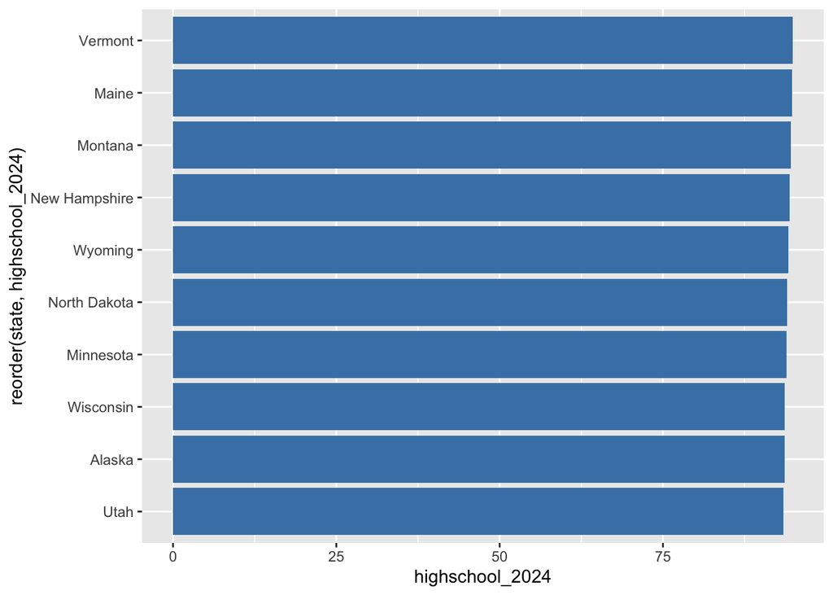

```r
  grad_clean %>%
  arrange(desc(highschool_2024)) %>%
  slice_head(n = 10) %>%
  ggplot(
    aes(
      reorder(state, highschool_2024),
      highschool_2024
    )
  ) +
  geom_col(fill = "steelblue") +
  coord_flip()
```

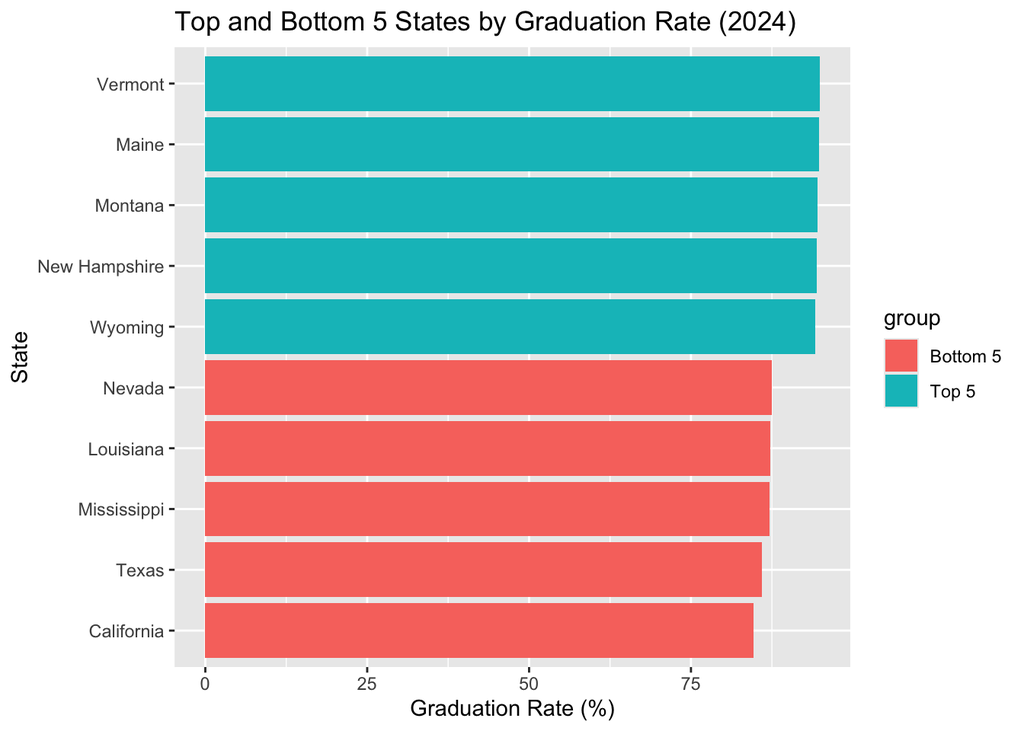

```r
grad_chart <- bind_rows(
  top5_grad %>% mutate(group = "Top 5"),
  bottom5_grad %>% mutate(group = "Bottom 5")
)

ggplot(
  grad_chart,
  aes(
    reorder(state, highschool_2024),
    highschool_2024,
    fill = group
  )
) +
  geom_col() +
  coord_flip() +
  labs(
    title = "Top and Bottom 5 States by Graduation Rate (2024)",
    x = "State",
    y = "Graduation Rate (%)"
  )
```

## **Dataset 2: SAT Scores**

The SAT dataset was also provided in a wide format where states were stored as columns and SAT measures were stored as rows. The dataset was transposed so that each state became an observation. The resulting dataset was then converted into a tidy format where SAT metrics and values were represented consistently.

```r
library(readr)
SAT_score <- read_csv("https://raw.githubusercontent.com/lioneljr17/LDATA607/refs/heads/main/Project2/SAT_score.csv")
#View(SAT_score)
head(SAT_score)
```

```
# A tibble: 4 × 54
  State Alabama Alaska Arizona Arkansas California Colorado Connecticut Delaware
  <chr> <chr>   <chr>  <chr>   <chr>    <chr>      <chr>    <chr>       <chr>
1 SAT … 3%      27%    10%     2%       26%        90%      91%         94%
2 Tota… 1172    1097   1194    1177     1096       987      989         933
3 Mean… 601     567    606     609      555        505      505         480
4 Mean… 570     530    588     568      541        482      484         453
# ℹ 45 more variables: `District of Columbia` <chr>, Florida <chr>,
#   Georgia <chr>, Hawaii <chr>, Idaho <chr>, Illinois <chr>, Indiana <chr>,
#   Iowa <chr>, Kansas <chr>, Kentucky <chr>, Louisiana <chr>, Maine <chr>,
#   Maryland <chr>, Massachusetts <chr>, Michigan <chr>, Minnesota <chr>,
#   Mississippi <chr>, Missouri <chr>, Montana <chr>, Nebraska <chr>,
#   Nevada <chr>, `New Hampshire` <chr>, `New Jersey` <chr>,
#   `New Mexico` <chr>, `New York` <chr>, `North Carolina` <chr>, …
```

```r
sat_clean <- SAT_score %>%
  column_to_rownames("State") %>%
  t() %>%
  as.data.frame() %>%
  rownames_to_column("state")

names(sat_clean) <- c(
  "state",
  "participation_rate",
  "total_mean_score",
  "reading_score",
  "math_score"
)
head(sat_clean)
```

```
       state participation_rate total_mean_score reading_score math_score
1    Alabama                 3%             1172           601        570
2     Alaska                27%             1097           567        530
3    Arizona                10%             1194           606        588
4   Arkansas                 2%             1177           609        568
5 California                26%             1096           555        541
6   Colorado                90%              987           505        482
```

```r
sat_clean <- sat_clean %>%
  mutate(
    participation_rate =
      as.numeric(gsub("%","",na_if(participation_rate,"N/A"))),
    total_mean_score =
      as.numeric(total_mean_score),
    reading_score =
      as.numeric(reading_score),
    math_score =
      as.numeric(math_score)
  )

sat_tidy <- sat_clean %>%
  pivot_longer(
    -state,
    names_to = "metric",
    values_to = "value"
  )
```

```r
top5_sat <- sat_clean %>%
  arrange(desc(total_mean_score)) %>%
  slice_head(n = 5)

top5_sat
```

```
         state participation_rate total_mean_score reading_score math_score
1 North Dakota                  1             1254           631        623
2     Nebraska                  1             1249           630        619
3    Wisconsin                  2             1240           624        616
4       Kansas                  2             1238           626        612
5      Wyoming                  1             1234           638        597
```

```r
bottom5_sat <- sat_clean %>%
  arrange(total_mean_score) %>%
  slice_head(n = 5)

sat_chart <- bind_rows(
  top5_sat %>% mutate(group = "Top 5"),
  bottom5_sat %>% mutate(group = "Bottom 5")
)
bottom5_sat
```

```
          state participation_rate total_mean_score reading_score math_score
1    New Mexico                100              875           451        424
2 West Virginia                 93              911           474        437
3      Delaware                 94              933           480        453
4  Rhode Island                 99              935           481        455
5       Indiana                100              950           485        464
```

```r
sat_clean %>%
  arrange(desc(total_mean_score)) %>%
  slice_head(n = 10)
```

[output not shown]

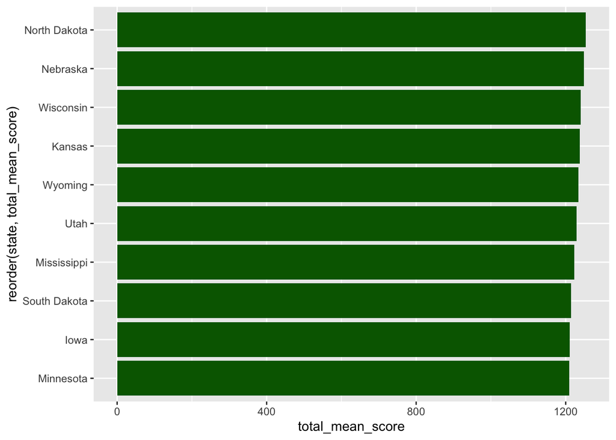

```r
sat_clean %>%
  arrange(desc(total_mean_score)) %>%
  slice_head(n = 10) %>%
  ggplot(
    aes(
      reorder(state,total_mean_score),
      total_mean_score
    )
  ) +
  geom_col(fill = "darkgreen") +
  coord_flip()
```

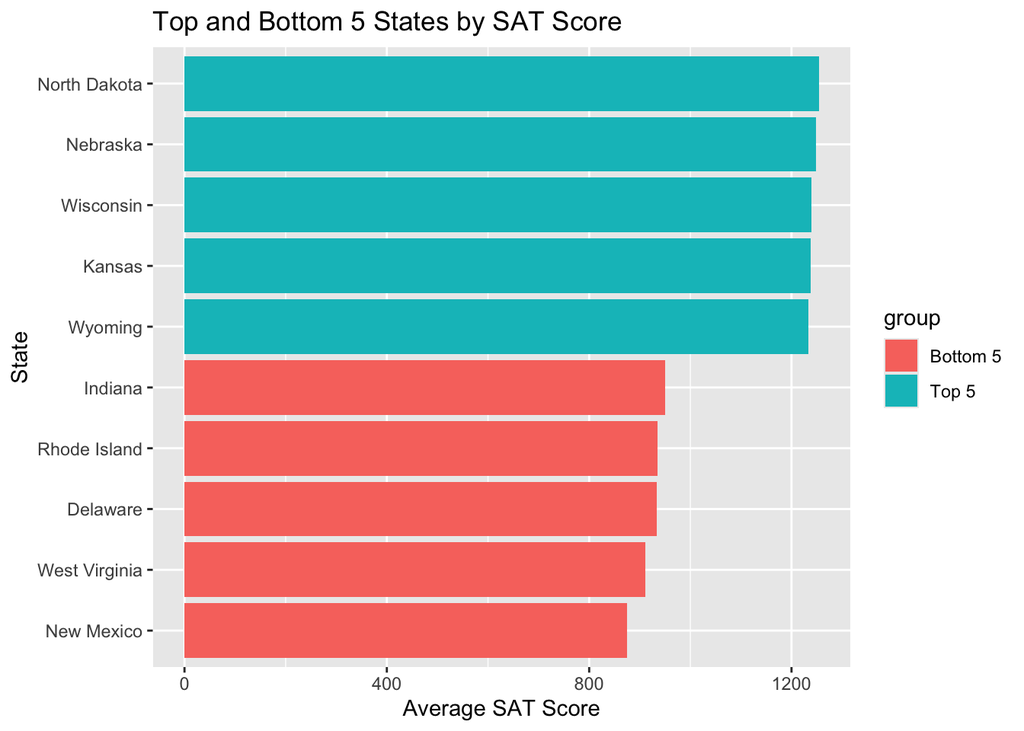

```r
ggplot(
  sat_chart,
  aes(
    reorder(state, total_mean_score),
    total_mean_score,
    fill = group
  )
) +
  geom_col() +
  coord_flip() +
  labs(
    title = "Top and Bottom 5 States by SAT Score",
    x = "State",
    y = "Average SAT Score"
  )
```

## **Dataset 3: School Funding**

The education funding dataset contained states as columns and funding categories as rows. Similar to the previous datasets, the data was transposed so that states became observations. The funding measures were then standardized and converted to numeric values after removing currency symbols.

```r
library(readr)
states_school_funding <- read_csv("https://raw.githubusercontent.com/lioneljr17/LDATA607/refs/heads/main/Project2/states_school_funding.csv")
#View(states_school_funding)

head(states_school_funding)
```

```
# A tibble: 2 × 52
  State Alabama Alaska Arizona Arkansas California Colorado Connecticut Delaware
  <chr> <chr>   <chr>  <chr>   <chr>    <chr>      <chr>    <chr>       <chr>
1 Tota… $2,866… $426.… $6,716… $1,467.… $19,701.13 $3,092.… $2,180.38   $503.58
2 Dire… $1,526… $60.31 $3,844… $686.77  $8,854.55  $1,806.… $1,244.52   $248.95
# ℹ 43 more variables: `District of Columbia` <chr>, Florida <chr>,
#   Georgia <chr>, Hawaii <chr>, Idaho <chr>, Illinois <chr>, Indiana <chr>,
#   Iowa <chr>, Kansas <chr>, Kentucky <chr>, Louisiana <chr>, Maine <chr>,
#   Maryland <chr>, Massachusetts <chr>, Michigan <chr>, Minnesota <chr>,
#   Mississippi <chr>, Missouri <chr>, Montana <chr>, Nebraska <chr>,
#   Nevada <chr>, `New Hampshire` <chr>, `New Jersey` <chr>,
#   `New Mexico` <chr>, `New York` <chr>, `North Carolina` <chr>, …
```

```r
school_funding_clean <- states_school_funding %>%
  column_to_rownames("State") %>%
  t() %>%
  as.data.frame() %>%
  rownames_to_column("state")

names(school_funding_clean) <- c(
  "state",
  "total_budget",
  "direct_student_loans"
)

school_funding_clean <- school_funding_clean %>%
  mutate(
    total_budget =
      as.numeric(gsub("[$,]","",total_budget)),
    direct_student_loans =
      as.numeric(gsub("[$,]","",direct_student_loans))
  )

funding_tidy <- school_funding_clean %>%
  pivot_longer(
    -state,
    names_to = "funding_type",
    values_to = "amount"
  )
```

```r
top5_funding <- school_funding_clean %>%
  arrange(desc(total_budget)) %>%
  slice_head(n = 5)
top5_funding
```

```
         state total_budget direct_student_loans
1   California     19701.13              8854.55
2        Texas     13509.50              5213.89
3     New York     12087.25              6463.10
4      Florida     10104.82              4836.90
5 Pennsylvania      7552.27              4698.04
```

```r
bottom5_funding <- school_funding_clean %>%
  arrange(total_budget) %>%
  slice_head(n = 5)
bottom5_funding
```

```
         state total_budget direct_student_loans
1      Wyoming       281.36                77.06
2      Vermont       417.89               222.86
3       Alaska       426.36                60.31
4 North Dakota       451.90               202.73
5       Hawaii       500.48               193.92
```

```r
funding_chart <- bind_rows(
  top5_funding %>% mutate(group = "Top 5"),
  bottom5_funding %>% mutate(group = "Bottom 5")
)
```

```r
school_funding_clean %>%
  arrange(desc(total_budget)) %>%
  slice_head(n = 10)
```

```
          state total_budget direct_student_loans
1    California     19701.13              8854.55
2         Texas     13509.50              5213.89
3      New York     12087.25              6463.10
4       Florida     10104.82              4836.90
5  Pennsylvania      7552.27              4698.04
6      Illinois      7514.58              4036.74
7       Arizona      6716.04              3844.44
8          Ohio      5563.95              2898.07
9       Georgia      5405.03              2599.57
10     Virginia      4962.27              3022.01
```

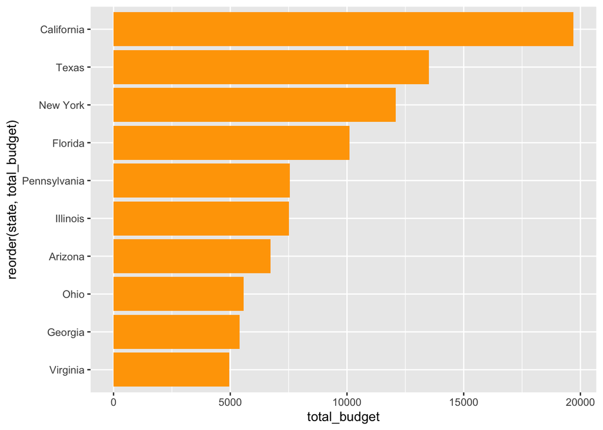

```r
school_funding_clean %>%
  arrange(desc(total_budget)) %>%
  slice_head(n = 10) %>%
  ggplot(
    aes(
      reorder(state,total_budget),
      total_budget
    )
  ) +
  geom_col(fill = "orange") +
  coord_flip()
```

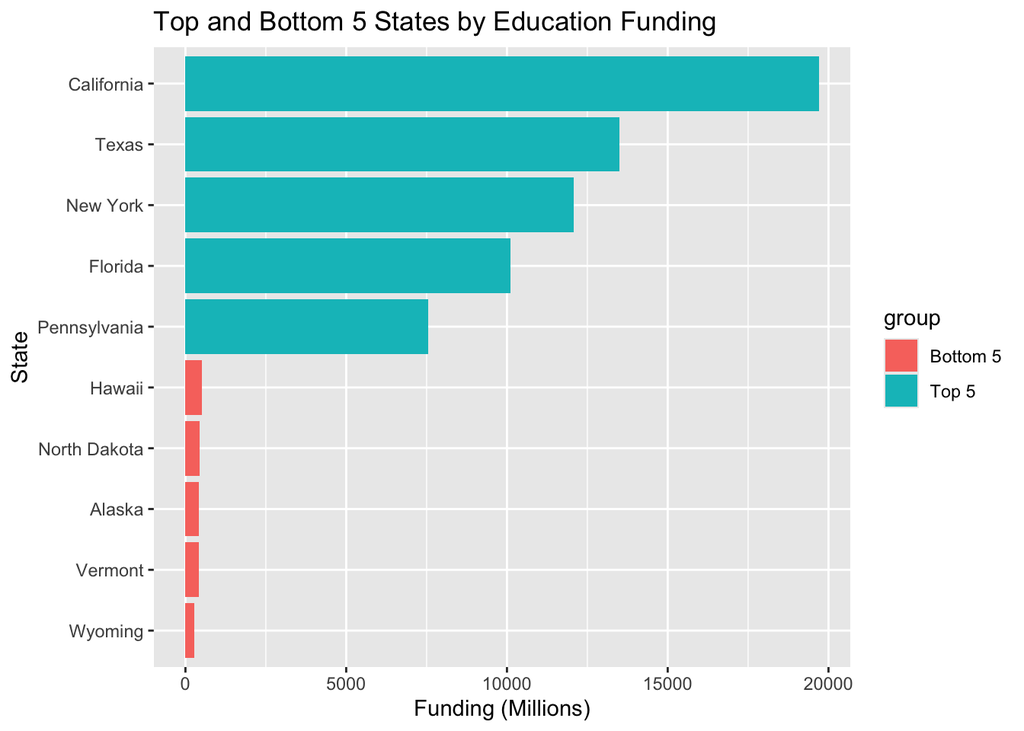

```r
ggplot(
  funding_chart,
  aes(
    reorder(state, total_budget),
    total_budget,
    fill = group
  )
) +
  geom_col() +
  coord_flip() +
  labs(
    title = "Top and Bottom 5 States by Education Funding",
    x = "State",
    y = "Funding (Millions)"
  )
```

## **Final Combined Analysis**

```r
combined_data <- grad_clean %>%
  select(
    state,
    highschool_2024
  ) %>%
  inner_join(
    sat_clean %>%
      select(
        state,
        total_mean_score
      ),
    by = "state"
  ) %>%
  inner_join(
    school_funding_clean %>%
      select(
        state,
        total_budget
      ),
    by = "state"
  )
```

```r
combined_data %>%
  arrange(desc(total_mean_score))
```

```
                  state highschool_2024 total_mean_score total_budget
1          North Dakota            94.0             1254       451.90
2              Nebraska            92.2             1249      1160.46
3             Wisconsin            93.6             1240      2394.88
4                Kansas            92.0             1238      1452.06
5               Wyoming            94.2             1234       281.36
6                  Utah            93.4             1229      2728.52
7           Mississippi            87.1             1223      1693.30
8          South Dakota            93.2             1214       533.42
9                  Iowa            93.3             1211      1703.16
10            Minnesota            93.9             1210      3948.58
11              Montana            94.6             1205       505.06
12            Louisiana            87.3             1195      2914.63
13              Arizona            89.4             1194      6716.04
14            Tennessee            90.0             1189      3595.99
```

[output cut: 37 more lines]

```r
  combined_data %>%
  select(
    highschool_2024,
    total_mean_score,
    total_budget
  ) %>%
  cor(
    use = "complete.obs"
  )
```

```
                 highschool_2024 total_mean_score total_budget
highschool_2024        1.0000000        0.1966690   -0.5515099
total_mean_score       0.1966690        1.0000000   -0.2010645
total_budget          -0.5515099       -0.2010645    1.0000000
```

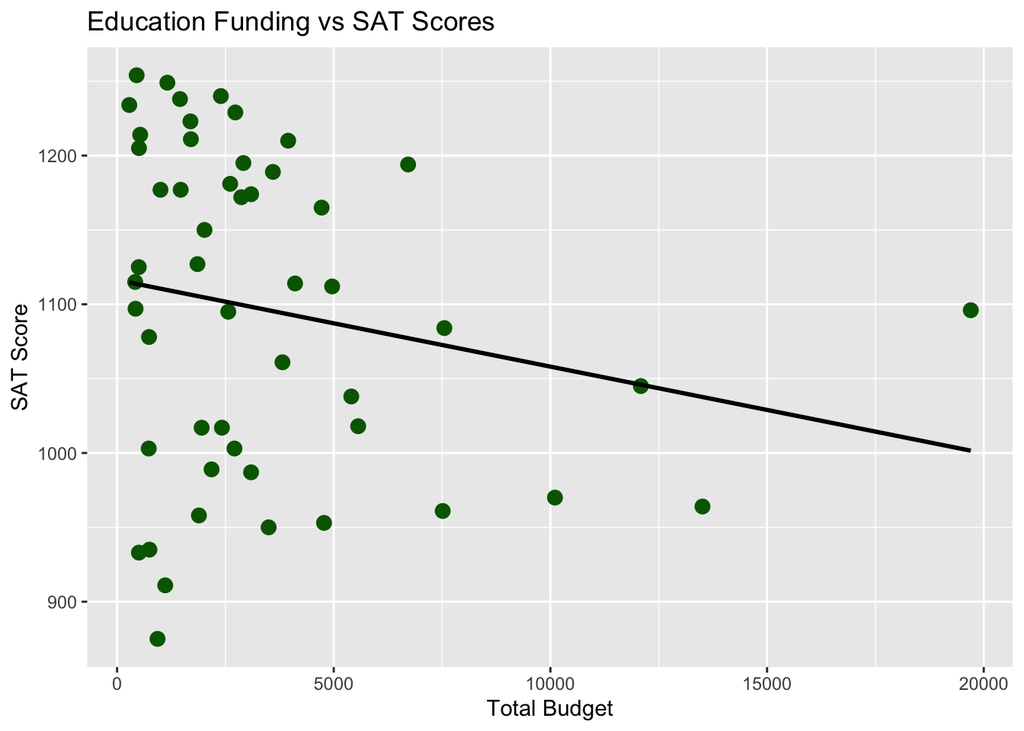

```r
ggplot(
  combined_data,
  aes(
    total_budget,
    total_mean_score
  )
) +
  geom_point(
    color = "darkgreen",
    size = 3
  ) +
  geom_smooth(
    method = "lm",
    se = FALSE,
    color = "black"
  ) +
  labs(
    title = "Education Funding vs SAT Scores",
    x = "Total Budget",
    y = "SAT Score"
  )
```

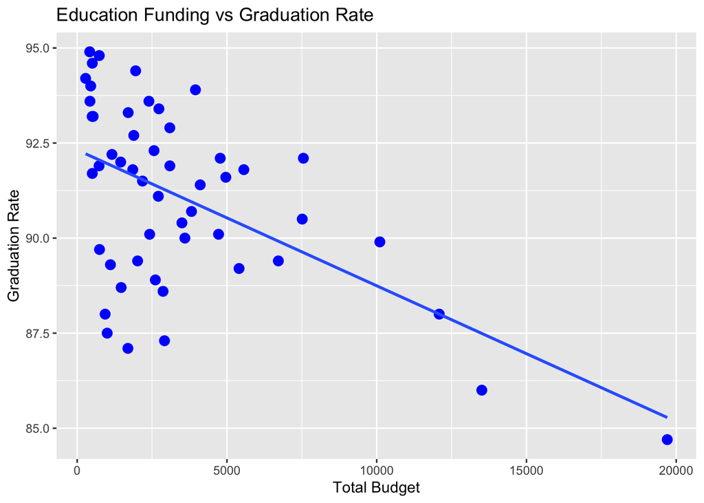

```r
ggplot(
  combined_data,
  aes(
    total_budget,
    highschool_2024
  )
) +
  geom_point(
    color = "blue",
    size = 3
  ) +
  geom_smooth(
    method = "lm",
    se = FALSE
  ) +
  labs(
    title = "Education Funding vs Graduation Rate",
    x = "Total Budget",
    y = "Graduation Rate"
  )
```

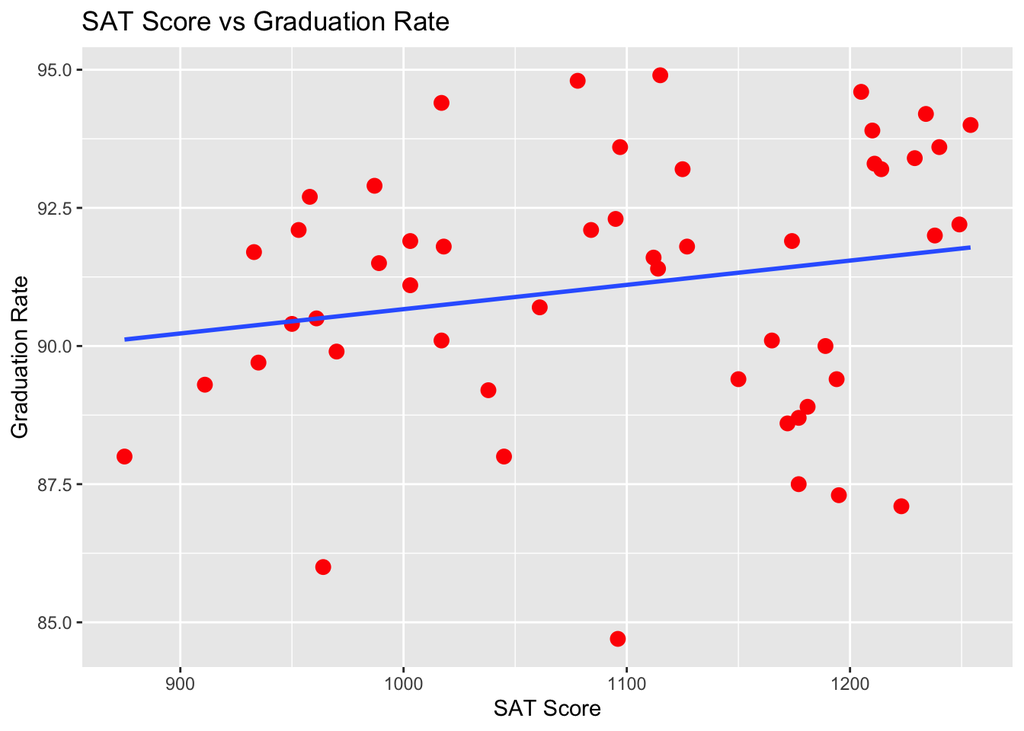

```r
ggplot(
  combined_data,
  aes(
    total_mean_score,
    highschool_2024
  )
) +
  geom_point(
    color = "red",
    size = 3
  ) +
  geom_smooth(
    method = "lm",
    se = FALSE
  ) +
  labs(
    title = "SAT Score vs Graduation Rate",
    x = "SAT Score",
    y = "Graduation Rate"
  )
```

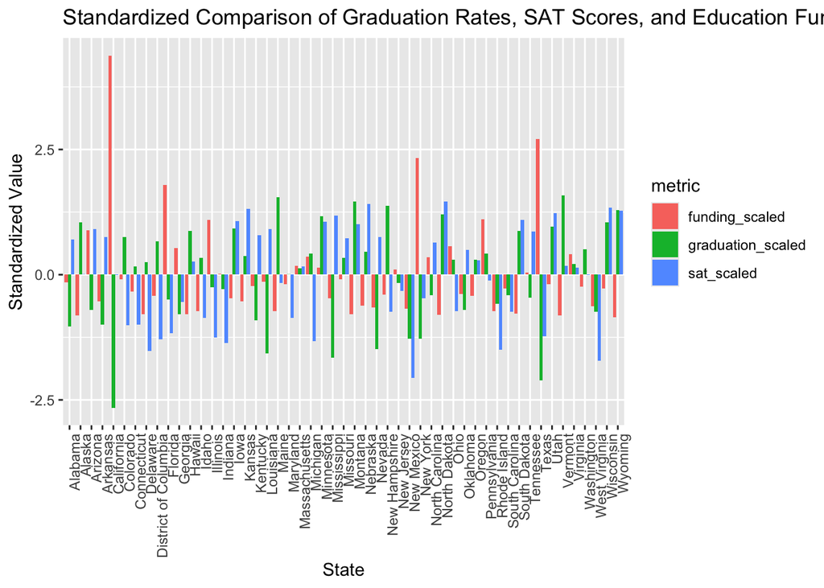

```r
combined_scaled <- combined_data %>%
  mutate(
    graduation_scaled =
      scale(highschool_2024)[,1],
    sat_scaled =
      scale(total_mean_score)[,1],
    funding_scaled =
      scale(total_budget)[,1]
  )


  combined_scaled_long <- combined_scaled %>%
  select(
    state,
    graduation_scaled,
    sat_scaled,
    funding_scaled
  ) %>%
  pivot_longer(
    -state,
    names_to = "metric",
    values_to = "value"
  )


  ggplot(
    combined_scaled_long,
    aes(
      state,
      value,
      fill = metric
    )
  ) +
  geom_col(position = "dodge") +
  theme(
    axis.text.x =
      element_text(
        angle = 90,
        hjust = 1
      )
  ) +
  labs(
    title = "Standardized Comparison of Graduation Rates, SAT Scores, and Education Funding",
    x = "State",
    y = "Standardized Value"
  )
```

## Conclusion

The independent analyses identified states with the highest graduation rates, SAT scores, and education funding levels. After combining the datasets, the results suggest that some relationship may exist between educational investment and academic outcomes. However, the strength of these relationships varies across states, suggesting that funding alone may not fully account for differences in graduation rates and SAT performance. Additional factors such as demographics, participation rates, and educational policies likely contribute to student outcomes.